# Reducción Dimensionalidad - PCA: provincias_variado

INE-S.G. Difusión

# Introducción

## dataset

En este cuaderno vamos a analizar el dataset llamado [*variado_provincias.xlsx*](https://github.com/davidperezros/ine_sg_difusion_explica_datasets/blob/eb97e3d6c8377207df61eece337eb3b9244ef003/Datasets/variado_provincias.xlsx). Este dataset presenta datos para las provincias, abordando información diversa sobre variables socioeconómicas. Contiene datos como número de explotaciones agrícolas, superficies agrícolas, indicadores de empleo, ejecuciones hipotecarias, empresas por sector, PIB per cápita y datos demográficos.

Concretamente en este dataset tenemos las siguientes variables:

Si tomamos demasiadas variables es difícil visualizar relaciones entre ellas. Otro problema que se presenta es la fuerte correlación. Se hace necesario, pues, reducir el número de variables sin perder información. Es importante resaltar el hecho de que el concepto de mayor información se relaciona con el de mayor variabilidad o varianza.

```r
# Librerias
library(readxl) # Para leer los excels
library(dplyr) # Para tratamiento de dataframes
library(ggplot2) # Nice plots
library(factoextra) # fviz_cluster function
library(skimr) # Para funcion skim
library(ggcorrplot) # Para funcion ggcorrplot
library(corrplot) # Para corrplot
```

Cargamos entonces el conjunto de datos:

```r
datos <- read_excel("/Users/davpero/ine_sg_difusion_explica_datasets/Datasets/provincias_variado.xlsx", sheet = "Datos")
```

## Descripción del trabajo a realizar

**(Esto irá en la web de explica)** Se pretende hacer un Análisis de Reducción de la Dimensionalidad empleando el procedimiento de Componentes Principales. El objetivo es conocer que variables independientes son de interés para estudiar las variables socioeconómicas de las provincias y ver cuáles son las más parecidas y las más diferentes.

- Hacer un análisis exploratorio explorando matriz de correlaciones.
- Ver si es necesario escalar/centrar los datos antes de aplicar pca y decidir si hacerlo con matriz de correlaciones o covarianzas.
- Seleccionar un determinado número de componentes y ver como influyen las variables en estas.
- Interpretar componentes y resultados.

# Análisis Exploratorio (EDA[^1])

En primer lugar, cargamos los datos que vamos a utilizar. En este caso, se trata de un conjunto de datos compuesto por 52 filas y 23 columnas. Las filas corresponden a las 52 provincias de España.

Antes de comenzar a aplicar la técnica, comprobamos si hay valores perdidos, por si fuera necesario realizar algún preproceso. En este caso, y como vemos a continuación, no hay ningún NA en los datos que vamos a utilizar.

```r
sum(is.na(datos))
```

```
## [1] 0
```

Por otra parte, para tener una noción general que nos permita describir el conjunto con el que vamos a trabajar, podemos extraer su dimensión, el tipo de variables que contiene o qué valores toma cada una.

```r
# Dimensión del conjunto de datos
dim(datos)
```

```
## [1] 52 23
```

```r
# Tipo de variables que contiene
str(datos)
```

```
## tibble [52 × 23] (S3: tbl_df/tbl/data.frame)
##  $ prov  : chr [1:52] "Almería" "Cádiz" "Córdoba" "Granada" ...
##  $ neag  : chr [1:52] "22697" "10069" "36641" "41243" ...
##  $ sagt  : chr [1:52] "327346" "540571" "1024515" "75827" ...
##  $ sagu  : chr [1:52] "234621" "424849" "844019" "625674" ...
##  $ benf  : num [1:52] 38299 75582 62023 60393 41255 ...
##  $ acem  : chr [1:52] "4383367.9299999988" "5611899.9800000004" "9458693.4799999986" "4635804.6700000009" ...
##  $ acti  : num [1:52] 341 563 371 429 250 ...
##  $ ocup  : num [1:52] 281 423 285 334 195 ...
##  $ para  : num [1:52] 67.2 155 95.8 105.6 58.9 ...
##  $ ejec  : num [1:52] 2026 454 193 906 269 ...
##  $ inds  : num [1:52] 2135 2982 4196 3494 1378 ...
##  $ cnst  : num [1:52] 5703 5916 5198 7240 2682 ...
##  $ ctrh  : num [1:52] 18704 27266 20196 24650 11559 ...
##  $ serv  : num [1:52] 17550 27210 18736 26000 10136 ...
##  $ pibc  : num [1:52] 19919 18050 18525 18181 20273 ...
##  $ ipib  : num [1:52] 0.773 0.7 0.719 0.705 0.787 ...
##  $ inmi  : num [1:52] 8013 6119 2966 6628 3830 ...
##  $ pobl  : num [1:52] 716820 1240155 782979 914678 521870 ...
##  $ espa  : num [1:52] 570912 1194830 761876 853709 477032 ...
##  $ d_migr: num [1:52] 1 0 0 0 0 0 1 0 1 0 ...
##  $ d_prod: num [1:52] 0 0 0 0 0 0 0 0 1 0 ...
##  $ d_cons: num [1:52] 0 0 0 0 0 0 0 0 1 1 ...
##  $ m_ieag: num [1:52] 0 1 1 1 -1 -1 -1 1 0 0 ...
```

```r
# Descripción de las variables
skim(datos)
```

Data summary

| Name | datos |
| --- | --- |
| Number of rows | 52 |
| Number of columns | 23 |
| _______________________ |  |
| Column type frequency: |  |
| character | 5 |
| numeric | 18 |
| ________________________ |  |
| Group variables | None |

**Variable type: character**

| skim_variable | n_missing | complete_rate | min | max | empty | n_unique | whitespace |
| --- | --- | --- | --- | --- | --- | --- | --- |
| prov | 0 | 1 | 4 | 21 | 0 | 52 | 0 |
| neag | 0 | 1 | 2 | 5 | 0 | 51 | 0 |
| sagt | 0 | 1 | 2 | 7 | 0 | 51 | 0 |
| sagu | 0 | 1 | 2 | 7 | 0 | 51 | 0 |
| acem | 0 | 1 | 1 | 18 | 0 | 50 | 0 |

**Variable type: numeric**

| skim_variable | n_missing | complete_rate | mean | sd | p0 | p25 | p50 | p75 | p100 | hist |
| --- | --- | --- | --- | --- | --- | --- | --- | --- | --- | --- |
| benf | 0 | 1 | 35790.39 | 38911.87 | 2073.42 | 9123.73 | 24705.08 | 49636.92 | 176383.92 | ▇▂▁▁▁ |
| acti | 0 | 1 | 442.83 | 609.12 | 38.05 | 149.77 | 276.54 | 493.32 | 3467.15 | ▇▁▁▁▁ |
| ocup | 0 | 1 | 380.37 | 540.79 | 27.80 | 133.58 | 241.15 | 425.17 | 3098.95 | ▇▁▁▁▁ |
| para | 0 | 1 | 68.86 | 80.66 | 3.50 | 17.77 | 42.92 | 77.59 | 411.68 | ▇▂▁▁▁ |
| ejec | 0 | 1 | 528.62 | 680.43 | 2.00 | 64.50 | 255.00 | 683.25 | 2859.00 | ▇▁▁▁▁ |
| inds | 0 | 1 | 3761.83 | 4607.44 | 73.00 | 1649.50 | 2751.50 | 4196.25 | 26217.00 | ▇▁▁▁▁ |
| cnst | 0 | 1 | 8079.19 | 10903.03 | 294.00 | 2751.75 | 4992.50 | 8314.00 | 60387.00 | ▇▁▁▁▁ |
| ctrh | 0 | 1 | 23348.52 | 30259.96 | 1960.00 | 8478.75 | 15599.00 | 27100.25 | 158817.00 | ▇▁▁▁▁ |
| serv | 0 | 1 | 30280.23 | 53485.83 | 1518.00 | 8868.75 | 15584.00 | 30357.75 | 311858.00 | ▇▁▁▁▁ |
| pibc | 0 | 1 | 23959.60 | 4866.02 | 18050.00 | 20267.50 | 22399.00 | 27906.25 | 36404.00 | ▇▃▃▂▁ |
| ipib | 0 | 1 | 0.93 | 0.19 | 0.70 | 0.79 | 0.87 | 1.08 | 1.41 | ▇▃▃▂▁ |
| inmi | 0 | 1 | 9181.77 | 16878.59 | 255.00 | 1798.00 | 3268.50 | 8871.00 | 97106.00 | ▇▁▁▁▁ |
| pobl | 0 | 1 | 904350.15 | 1188191.60 | 84777.00 | 326389.75 | 607321.00 | 1025345.75 | 6663394.00 | ▇▁▁▁▁ |
| espa | 0 | 1 | 807487.12 | 1027974.94 | 73221.00 | 299280.50 | 559603.50 | 917612.50 | 5781575.00 | ▇▁▁▁▁ |
| d_migr | 0 | 1 | 0.50 | 0.50 | 0.00 | 0.00 | 0.50 | 1.00 | 1.00 | ▇▁▁▁▇ |
| d_prod | 0 | 1 | 0.35 | 0.48 | 0.00 | 0.00 | 0.00 | 1.00 | 1.00 | ▇▁▁▁▅ |
| d_cons | 0 | 1 | 0.48 | 0.50 | 0.00 | 0.00 | 0.00 | 1.00 | 1.00 | ▇▁▁▁▇ |
| m_ieag | 0 | 1 | 0.04 | 0.84 | -1.00 | -1.00 | 0.00 | 1.00 | 1.00 | ▇▁▇▁▇ |

Vemos que hay alguna provincia como Ceuta y Melilla con datos faltantes, luego los eliminamos y posteriormente convertimos a variable numérica las que han sido consideradas como caracter(debido a los fallos para Ceuta y Melilla) y deberían ser variables numéricas.

```r
# Ceuta y Melilla tienen datos faltantes luego eliminamos observaciones
datos <-datos[ datos$prov != "Ceuta" ,]
datos <-datos[ datos$prov != "Melilla" ,]

# Convertimos a variables numéricas
datos$acem <- as.numeric(datos$acem)
datos$neag <- as.numeric(datos$neag)
datos$sagt <- as.numeric(datos$sagt)
datos$sagu <- as.numeric(datos$sagu)
```

**Correlación:** El que existan correlaciones muy elevadas en el conjunto de datos nos permitirá resumir la información en un menor número de componentes principales, pues éstas explicarán una mayor cantidad de información.

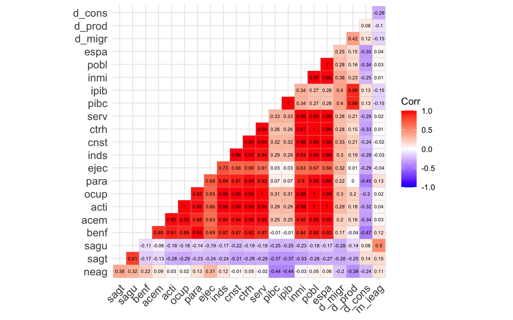

```r
ggcorrplot(cor(datos[, 2:23]), type = "lower", lab = T, show.legend = T, lab_size = 1.9)
```

En este caso, se ha generado un gráfico entre variables, sin tener en cuenta la correlación de la variable consigo misma, pues siempre será del 100%. En términos absolutos, vemos lo siguiente:

- Las variables *sagt* y *sagu* presentan una correlación alta lo que parece razonable. puesto que ambas están relacionadas con superficies agrícolas.
- Por otro lado, se encuentran también bastante correlacionadas entre ellas *benf*, *acem*, *acti*, *ocup*, *para*, *ejec*, *inds*, *cnst* y *ctrh*, las cuales hablan sobre la actividad económica, el mercado laboral y la situación financiera.
- Además, las variables *inmi*, *pobl*, *espa* que hablan sobre población se encuentran correlacionadas con las variables socioeconómicas citadas antes.

En general es un dataset que presenta variables con bastante correlación luego esto, probablemente, nos permitirá reducir bastante el numéro de variables finales.

# Reducción Dimensionalidad: Componentes Principales

## Introducción

El **Análisis de Componentes Principales (PCA)** es una técnica para reducir la complejidad de conjuntos de datos con múltiples variables. Su objetivo es transformar variables correlacionadas en un conjunto menor de dimensiones sin perder la mayor parte de la información original.

Se busca encontrar **nuevas variables (componentes)** que estén incorrelacionadas y que capturen la máxima variabilidad de los datos. Esto se logra mediante combinaciones lineales de las variables originales. PCA es útil para entender relaciones, reducir dimensiones y manejar la alta correlación entre variables.

Para aplicar PCA, se necesitan **datos cuantitativos** y es crucial *escalar las variables* (estandarizar = media cero y varianza uno). Esto garantiza que ninguna variable domine el análisis. Además, se puede trabajar con la matriz de correlaciones para abordar fuertes correlaciones entre variables, manteniendo así la información más relevante del conjunto de datos.

Los pasos generales son:

1. **Estandarización de las variables**: Es importante estandarizar las variables numéricas para que tengan media cero y desviación estándar uno. Esto es crucial para que ninguna variable domine el análisis debido a su escala.
2. **Cálculo de la matriz de correlaciones o covarianzas**: Dependiendo del enfoque, se puede trabajar con la matriz de correlaciones si se busca abordar fuertes correlaciones entre variables, o con la matriz de covarianzas si se busca la varianza total de las variables.
- **NOTA**: Aconsejable trabajar siempre con la matriz de correlaciones (a no ser que todas variables estén en las mismas unidades, que se podrá usar la matriz de covarianzas). De no seguir esta nota y usar la matriz de covarianzas, las variables que tienen mayores unidades dominarán la estructura de covarianza, lo que llevará a una representación inexacta de la variabilidad real de los datos.
3. **Descomposición de la matriz**: Se descompone la matriz de correlaciones en sus vectores y valores propios. Los valores propios representan la cantidad de varianza explicada por cada componente principal, mientras que los vectores propios (autovectores) determinan la dirección de cada componente en el espacio multidimensional original.
4. **Selección de componentes**: Los componentes se ordenan de manera descendente según la cantidad de varianza que explican. Los primeros componentes capturan la mayor variabilidad de los datos y se seleccionan para reducir la dimensionalidad manteniendo la información más relevante.
5. **Transformación de datos**: Proyectar los datos originales en el espacio de los componentes principales para obtener las nuevas variables. Estas son combinaciones lineales de las variables originales y son ortogonales entre sí. Esta transformación lineal **conserva la mayor parte de la información en un espacio de menor dimensión, lo que facilita el análisis y la visualización de los datos**.
6. **Interpretación y visualización**: Explorar la importancia de cada componente en términos de la variabilidad explicada. Se pueden interpretar los componentes para comprender qué aspectos de los datos capturan. Si es posible, representar gráficamente los datos en el espacio reducido de los componentes principales para obtener una mejor comprensión de las relaciones entre las observaciones.

## Modelo

En las siguientes lineas haremos que la variable `prov` se ponga como nombre de filas y posteriormente eliminaremos esa variable ya que ya la tendremos como nombre de filas.

```r
prov <- datos$prov
datos <- datos[, -1] # Eliminamos ahora
rownames(datos) <- prov # Como nombres de filas las provincias
```

Escalamos los datos y calculamos la matriz de varianzas covarianzas, mostramos solo la diagonal (debería ser 1).

```r
datos2 <- scale(datos)
summary(datos2)
```

```
##       neag              sagt              sagu              benf
##  Min.   :-1.1411   Min.   :-1.3485   Min.   :-1.1733   Min.   :-0.8942
##  1st Qu.:-0.6411   1st Qu.:-0.7553   1st Qu.:-0.7755   1st Qu.:-0.6871
##  Median :-0.3091   Median :-0.1222   Median :-0.1540   Median :-0.2694
##  Mean   : 0.0000   Mean   : 0.0000   Mean   : 0.0000   Mean   : 0.0000
##  3rd Qu.: 0.5315   3rd Qu.: 0.7954   3rd Qu.: 0.5506   3rd Qu.: 0.3504
##  Max.   : 3.3341   Max.   : 2.7318   Max.   : 3.0203   Max.   : 3.5591
##       acem                acti               ocup               para
##  Min.   :-0.617472   Min.   :-0.67366   Min.   :-0.64655   Min.   :-0.8301
##  1st Qu.:-0.479423   1st Qu.:-0.49119   1st Qu.:-0.46230   1st Qu.:-0.6437
##  Median :-0.283360   Median :-0.26519   Median :-0.27382   Median :-0.3165
##  Mean   : 0.000000   Mean   : 0.00000   Mean   : 0.00000   Mean   : 0.0000
##  3rd Qu.: 0.007602   3rd Qu.: 0.09655   3rd Qu.: 0.06362   3rd Qu.: 0.1086
##  Max.   : 4.544298   Max.   : 4.88489   Max.   : 4.94493   Max.   : 4.1806
##       ejec              inds               cnst               ctrh
##  Min.   :-0.7899   Min.   :-0.73202   Min.   :-0.68723   Min.   :-0.72021
##  1st Qu.:-0.6860   1st Qu.:-0.47413   1st Qu.:-0.48766   1st Qu.:-0.50005
##  Median :-0.4180   Median :-0.23058   Median :-0.29068   Median :-0.27136
##  Mean   : 0.0000   Mean   : 0.00000   Mean   : 0.00000   Mean   : 0.00000
##  3rd Qu.: 0.3064   3rd Qu.: 0.06218   3rd Qu.: 0.02612   3rd Qu.: 0.09904
##  Max.   : 3.3679   Max.   : 4.80833   Max.   : 4.72343   Max.   : 4.40407
##       serv               pibc              ipib              inmi
##  Min.   :-0.53903   Min.   :-1.2490   Min.   :-1.2490   Min.   :-0.531467
##  1st Qu.:-0.41091   1st Qu.:-0.7794   1st Qu.:-0.7794   1st Qu.:-0.441624
##  Median :-0.27930   Median :-0.3078   Median :-0.3078   Median :-0.345592
##  Mean   : 0.00000   Mean   : 0.0000   Mean   : 0.0000   Mean   : 0.000000
##  3rd Qu.:-0.01928   3rd Qu.: 0.7876   3rd Qu.: 0.7876   3rd Qu.:-0.007037
##  Max.   : 5.16964   Max.   : 2.5159   Max.   : 2.5159   Max.   : 5.113423
##       pobl               espa              d_migr            d_prod
##  Min.   :-0.70681   Min.   :-0.72798   Min.   :-0.9899   Min.   :-0.7425
##  1st Qu.:-0.50535   1st Qu.:-0.50227   1st Qu.:-0.9899   1st Qu.:-0.7425
##  Median :-0.24426   Median :-0.24694   Median : 0.0000   Median :-0.7425
##  Mean   : 0.00000   Mean   : 0.00000   Mean   : 0.0000   Mean   : 0.0000
##  3rd Qu.: 0.07776   3rd Qu.: 0.09517   3rd Qu.: 0.9899   3rd Qu.: 1.3199
##  Max.   : 4.77031   Max.   : 4.76444   Max.   : 0.9899   Max.   : 1.3199
##      d_cons            m_ieag
##  Min.   :-0.9899   Min.   :-1.2
##  1st Qu.:-0.9899   1st Qu.:-1.2
##  Median : 0.0000   Median : 0.0
##  Mean   : 0.0000   Mean   : 0.0
##  3rd Qu.: 0.9899   3rd Qu.: 1.2
##  Max.   : 0.9899   Max.   : 1.2
```

```r
diag(var(datos2))
```

```
##   neag   sagt   sagu   benf   acem   acti   ocup   para   ejec   inds   cnst
##      1      1      1      1      1      1      1      1      1      1      1
##   ctrh   serv   pibc   ipib   inmi   pobl   espa d_migr d_prod d_cons m_ieag
##      1      1      1      1      1      1      1      1      1      1      1
```

Aplicamos funcion PCA, notar que en este caso no haría falta los argumentos `SCALE=TRUE` y `CENTER=TRUE` puesto que ya hemos escalado dos datos en un paso previo. Por defecto en la función viene el valor de `SCALE=FALSE` y `CENTER=TRUE`.

```r
pca <- prcomp(datos2, center = TRUE, scale = TRUE) # Scale=T
```

**Calculamos los coeficientes de la ecuación para cada componente principal** (Autovectores)

```r
pca$rotation
```

```
##                 PC1          PC2         PC3          PC4         PC5
## neag   -0.008203669 -0.343875267  0.04530181  0.225703033 -0.54756484
## sagt    0.093777760 -0.260685812  0.46692515  0.349015155  0.03406050
## sagu    0.065567030 -0.244985221  0.61799140  0.097155168  0.02080531
## benf   -0.255547541 -0.169583054 -0.04259558 -0.052834575 -0.02213471
## acem   -0.267132603 -0.057835771  0.10183034  0.045780063  0.08580010
## acti   -0.281063977 -0.023526873  0.02628693  0.007544727  0.07970706
## ocup   -0.280841146 -0.008682980  0.03451402  0.018319293  0.08680006
## para   -0.266087680 -0.130432450 -0.03284853 -0.075401384  0.02454609
## ejec   -0.198849271 -0.099263733 -0.15594933  0.165381576 -0.45691677
## inds   -0.273655544 -0.025426864  0.02639828  0.104890737 -0.03003321
## cnst   -0.278652744  0.009442489  0.01045498  0.065833031  0.09797438
## ctrh   -0.280865532 -0.034425301 -0.00195234  0.028043173  0.06635140
## serv   -0.278225349  0.001691252  0.04777668  0.010808461  0.13573865
## pibc   -0.091357800  0.443739119  0.23824009 -0.056976256 -0.09063192
## ipib   -0.091357800  0.443739119  0.23824009 -0.056976256 -0.09063192
## inmi   -0.276330714  0.024554052  0.01362495  0.036421615  0.07966626
## pobl   -0.281059234 -0.031986886  0.01745440  0.009483160  0.07141424
## espa   -0.279916693 -0.041995882  0.02242889 -0.001685268  0.07871296
## d_migr -0.095504531  0.238686852 -0.03617703  0.252839323 -0.46455287
## d_prod -0.063526272  0.414171144  0.29841325 -0.067396952 -0.23173719
## d_cons  0.097819045  0.179380331  0.07889970  0.608464813  0.35133940
## m_ieag -0.003008870 -0.185386385  0.37995131 -0.562708171 -0.08435159
##                  PC6           PC7          PC8          PC9         PC10
## neag   -0.3439637614  0.3181931984  0.546633074 -0.042234946  0.061127320
## sagt   -0.1100455393 -0.4006638868 -0.117615869  0.039275911 -0.279051822
## sagu    0.0817036075 -0.0222447662 -0.171395080  0.026316824  0.157218184
## benf    0.0137041574 -0.0865694329 -0.029661792 -0.559030776 -0.309307488
## acem   -0.1178721638 -0.0707233983 -0.044543831  0.298833863  0.257966427
## acti    0.0076332457 -0.0037803382  0.059270911  0.005709252 -0.006149006
## ocup   -0.0006559353  0.0075506538  0.064643582  0.060016993  0.027810869
## para    0.0727358249 -0.0886662722  0.017717750 -0.382779446 -0.248294230
## ejec    0.0680105833  0.3147912020 -0.719248381  0.125707090 -0.074181682
## inds   -0.0628750541  0.0694423188 -0.072739992  0.084531854  0.006424920
## cnst    0.0292065917  0.0536723970  0.048498272  0.056468107  0.155876623
## ctrh   -0.0048832446  0.0017937693 -0.009848608 -0.004766928  0.012155773
## serv   -0.0012741045 -0.0048713916  0.087208561  0.112787351  0.132475098
## pibc   -0.1948383804  0.1087456789  0.051279330  0.143863566 -0.368945603
## ipib   -0.1948383804  0.1087456789  0.051279330  0.143863566 -0.368945603
## inmi    0.0914218309 -0.0061780392  0.133400292  0.163491527  0.196306238
```

[output cut: 60 more lines]

```
## para   -8.170016e-02  3.057609e-15
## ejec   -2.769442e-04 -1.767717e-16
## inds    1.329953e-03  1.024732e-15
## cnst   -3.981757e-03 -1.943094e-16
## ctrh   -1.114550e-05 -1.608394e-15
## serv    3.314180e-03 -1.242448e-15
## pibc   -1.612389e-04 -7.071068e-01
## ipib   -1.612389e-04  7.071068e-01
## inmi   -4.256775e-03  1.386952e-15
## pobl    9.689444e-03 -1.890031e-16
## espa   -1.459524e-02  1.434271e-15
## d_migr  1.544843e-04 -8.569799e-17
## d_prod  1.396581e-04  2.362785e-16
## d_cons  1.484576e-04  1.679163e-17
## m_ieag  1.993842e-04 -6.592012e-17
```

Podemos observar aquí nuestras variables en el nuevo sistema de cordenadas (las componentes principales), dando lugar a ecuaciones de cada eje como combinación lineal del total de variables. Analizar el vector que crea cada componente y cuáles son los pesos que tienen las variables en cada componente, ayuda a interpretar qué tipo de información recoge cada una de ellas.

**Extraemos las nuevas coordenadas de los individuos (puntuaciones)**

Además, podemos ver las puntuaciones, que son las coordenadas de cada observación original (provincia) sobre los nuevos ejes construidos (componentes principales). Esto corresponde a un cambio de coordenadas bajo el paradigma del Álgebra Lineal.

```r
pca$x
```

```
##                                PC1          PC2         PC3          PC4
## Almería                 0.14401049 -0.999448416 -1.77192463 -0.118079207
## Cádiz                  -0.22289523 -2.155904201 -0.55296161 -1.681361510
## Córdoba                 0.71449576 -3.057392226  0.93475214 -0.756650372
## Granada                 0.06790381 -2.584691109 -0.69960531 -1.361734406
## Huelva                  1.33834239 -0.664855530 -1.89207804 -0.457302506
## Jaén                    1.01640243 -2.477648245 -1.48041105  0.660901059
## Málaga                 -2.05022515 -0.647035376 -2.24235793 -0.007862319
## Sevilla                -2.51838871 -3.454148645  1.18516391 -0.602085790
## Huesca                  1.97302285  1.580980476  1.94498310  0.956907786
## Teruel                  2.60699292  0.258668522  0.78934459  0.287302608
## Zaragoza               -0.18690810  0.467955728  2.63600211 -0.601906654
## Asturias                0.12191259 -0.774813465 -0.94021810 -0.128738650
## Balears                -1.24991745  2.114845576  0.07006078  0.300984950
## Palmas, Las            -0.81168302 -0.345405772 -1.56426460 -1.821112545
## Sta. Cruz de Tenerife  -0.63600483 -0.069946598 -1.94786926 -1.052209647
## Cantabria               1.25502202  0.430431827 -1.20251616  0.663447751
## Ávila                   2.43630213 -0.270369492  0.03781298  0.025430154
## Burgos                  1.34815470  1.413677429  1.42118486 -2.278312648
## León                    1.83063398 -0.654370228 -0.03188379  1.354119970
## Palencia                2.26422590  1.523585181  1.57162124 -0.858533967
## Salamanca               2.10888368 -1.591010860  1.13009061 -1.212836056
## Segovia                 2.52541173 -0.009549252 -0.44096012  0.037138818
## Soria                   2.27848934  2.318162660  0.33886677  1.040220677
## Valladolid              1.18172729  0.717811692  1.48437900 -1.854683128
## Zamora                  2.66712842 -0.622525273 -0.56993495  1.106715098
## Albacete                1.70526297 -0.861167392 -1.11820623  0.103679629
## Ciudad Real             1.93806454 -2.103835255  1.87532831  1.535218859
## Cuenca                  2.39881775 -0.442048801  1.01283707  1.325191706
## Guadalajara             2.06687855  0.015477628 -0.60047816  0.686257932
## Toledo                  0.93628031 -2.175445418  1.10303675  1.302358185
## Barcelona             -14.43502394  0.413154985  0.22204504  1.201208938
## Girona                 -0.12932483  2.632853916 -0.56893082  0.954778051
## Lleida                  1.03296497  1.675225165  1.26233986  0.948179545
## Tarragona              -0.33434264  3.173908867 -0.65007300  0.886774348
## Alacant                -2.85383440 -1.018910215 -1.67455504  1.193787578
## Castelló                0.48607692  1.156090115 -0.23849448 -1.126779290
## València               -5.17978283 -2.362336409 -0.75443785  1.041869611
## Badajoz                 1.21111842 -3.893142228  2.89809711  0.024951961
## Cáceres                 2.11564555 -2.413147162  1.98230441  0.656030710
```

[output cut: 251 more lines]

```
## Castelló               7.785871e-04 -4.446089e-16
## València               9.704024e-04 -1.499293e-16
## Badajoz                8.804314e-04 -5.290910e-16
## Cáceres               -5.698375e-04 -3.996081e-16
## Coruña                 5.184729e-04 -2.262680e-16
## Lugo                  -2.016251e-04 -3.120915e-16
## Ourense               -4.945385e-04  2.779896e-16
## Pontevedra             4.975490e-04  1.935451e-16
## Madrid                 6.439874e-05 -4.108671e-17
## Murcia                 8.088999e-04 -2.928660e-17
## Nafarroa              -7.896884e-04  1.858374e-17
## Araba                  1.158608e-04 -2.034418e-16
## Bizkaia               -1.039056e-03  4.657018e-16
## Guipuzkoa             -1.413750e-04  2.548177e-16
## Rioja, La              8.665755e-04  3.683465e-16
```

Dando una interpretación a cada eje, podremos determinar qué perfil tiene cada provincia dentro del estudio.

**Varianza explicada por cada componente principal**

Una vez calculadas las componentes principales, es de interés conocer la varianza explicada por cada una, ya que el principal objetivo que se sigue con PCA es maximizar la cantidad de información explicada por las componentes.

```r
summary(pca)
```

```
## Importance of components:
##                           PC1    PC2     PC3     PC4     PC5     PC6     PC7
## Standard deviation     3.5372 1.9301 1.30707 1.07415 0.94777 0.87697 0.67992
## Proportion of Variance 0.5687 0.1693 0.07766 0.05244 0.04083 0.03496 0.02101
## Cumulative Proportion  0.5687 0.7380 0.81570 0.86815 0.90898 0.94394 0.96495
##                            PC8     PC9    PC10   PC11    PC12    PC13    PC14
## Standard deviation     0.54393 0.39540 0.32673 0.2965 0.22661 0.21293 0.10955
## Proportion of Variance 0.01345 0.00711 0.00485 0.0040 0.00233 0.00206 0.00055
## Cumulative Proportion  0.97840 0.98550 0.99036 0.9943 0.99669 0.99875 0.99929
##                           PC15    PC16    PC17    PC18    PC19    PC20
## Standard deviation     0.08876 0.05995 0.04795 0.03760 0.01773 0.00854
## Proportion of Variance 0.00036 0.00016 0.00010 0.00006 0.00001 0.00000
## Cumulative Proportion  0.99965 0.99981 0.99992 0.99998 1.00000 1.00000
##                             PC21      PC22
## Standard deviation     0.0008774 1.942e-16
## Proportion of Variance 0.0000000 0.000e+00
## Cumulative Proportion  1.0000000 1.000e+00
```

- **Standard deviation**: muestra las desviaciones estándar de cada componente principal. Si elevamos al cuadrado estas desviaciones, tenemos la varianza (**el autovalor correspondiente**). Es decir, la varianza explicada por cada componente corresponde con los autovalores de la matriz de covarianzas de los datos estandarizados.
- **Proportion of Variance**: es la proporción de la varianza total que explica cada componente principal y quizá, es la fila más importante de nuestros resultados. Como los autovalores están ordenados de mayor a menor y así son construidas las componentes principales, la primera componente principal es la que mayor porcentaje de variabilidad explica, un 56%. Así, la varianza explicada por la componentes van en orden decreciente, teniendo que la segunda componente explica un 16% y la tercera, un 7%.
- **Cumulative proportion**: es la varianza acumulada y se calcula progresivamente sumando la Proportion of Variance anterior. En vista de estos resultados, vemos que la primera componente agrupa el 56% de la variación, y que necesitamos 3 componentes para alcanzar el 81%.

Si elevamos al cuadrado estas desviaciones, tenemos la varianza (el **autovalor correspondiente**). Es decir, la varianza explicada por cada componente corresponde con los autovalores de la matriz de covarianzas de los datos estandarizados.

```r
# Autovalues
pca$sdev^2 # varianza de cada componente
```

```
##  [1] 1.251174e+01 3.725281e+00 1.708420e+00 1.153788e+00 8.982736e-01
##  [6] 7.690832e-01 4.622873e-01 2.958583e-01 1.563377e-01 1.067539e-01
## [11] 8.791102e-02 5.135091e-02 4.534131e-02 1.200170e-02 7.877692e-03
## [16] 3.593488e-03 2.299134e-03 1.413591e-03 3.143363e-04 7.292756e-05
## [21] 7.697824e-07 3.771517e-32
```

## Selección de componentes

Graficando el valor de la varianza de cada componente principal, podemos observar los resultados comentados anteriormente, que las primeras componentes son las que más varianza explican y que a medida que se añaden más, la varianza explicada por cada una es menor.

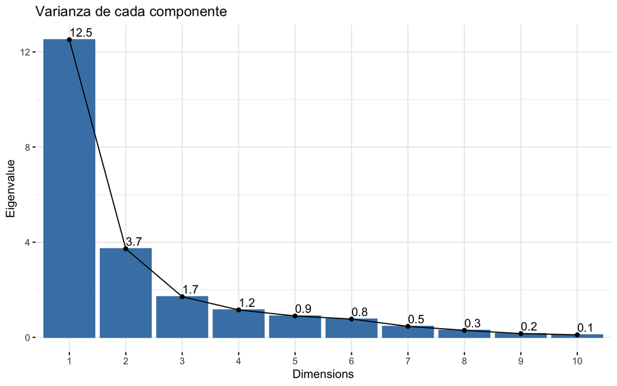

```r
fviz_eig(pca, main = "Varianza de cada componente", choice = "eigenvalue", addlabels = T)
```

o como el porcentaje de varianza explicada por cada componente sobre el total.

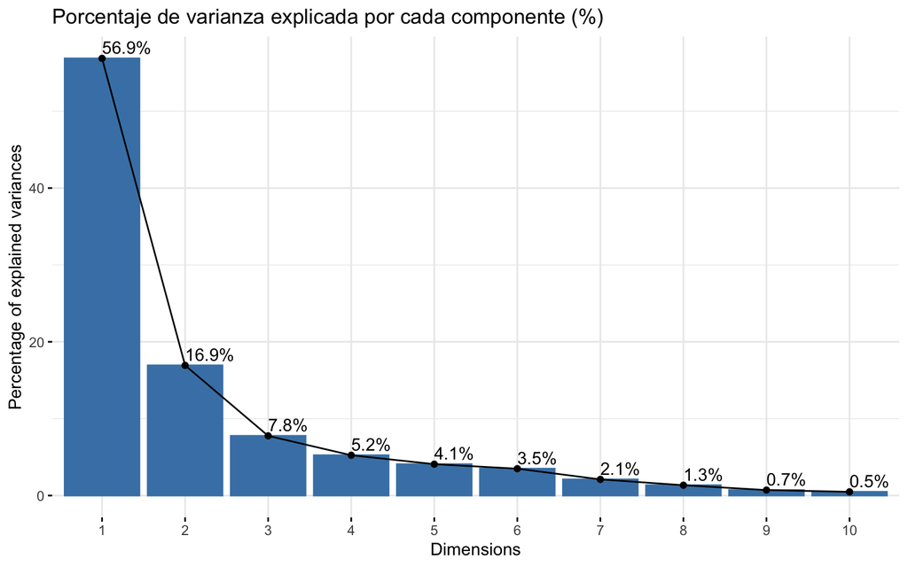

```r
fviz_screeplot(pca, addlabels = TRUE, main = "Porcentaje de varianza explicada por cada componente (%)")
```

A continuación, representamos las varianzas acumuladas:

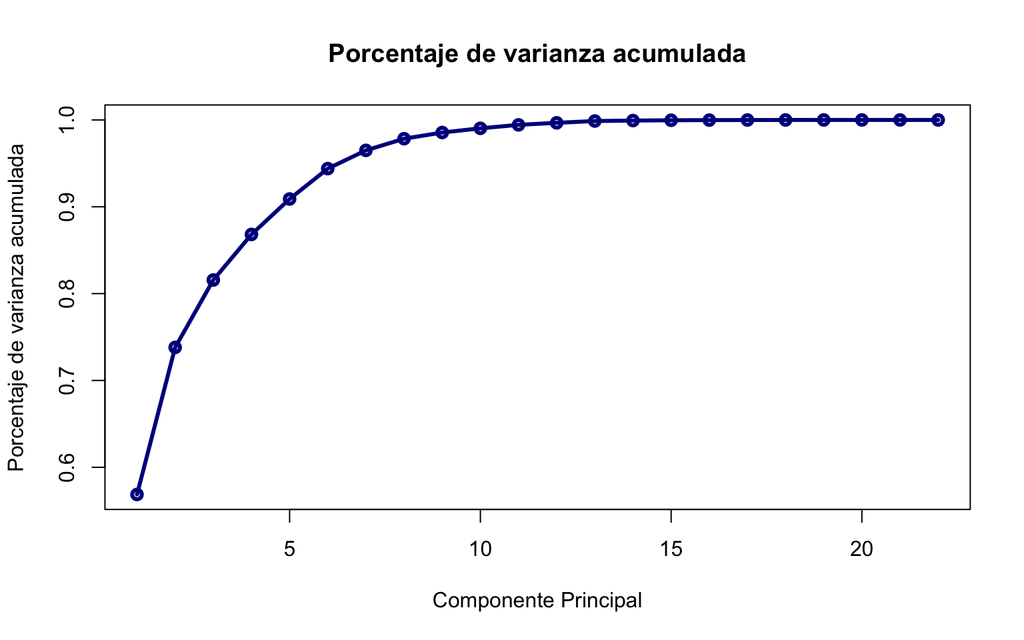

```r
plot(summary(pca)$importance[3, ], type = "o", col = "darkblue", lwd = 3, main = "Porcentaje de varianza acumulada", xlab = "Componente Principal", ylab = "Porcentaje de varianza acumulada")
```

Determinar el número de componentes que elegir para continuar con el análisis no tiene unas normas determinadas a seguir. Respecto a ello, existen varios criterios con sus respectivas propuestas.

1. Una opción para determinar el número de componentes principales que seleccionar, es coger aquellas tal que expliquemos un % **determinado de la variabilidad de los datos que nosotros prefijemos**. Generalmente se pone como umbral mínimo un 80%, entonces necesitaríamos elegir 3 componentes.
2. Otra posibilidad es seguir el **criterio de Kaisser**, que escoge aquellas componentes cuyo autovalor sea superior a 1 (cuando las variables han sido generadas a partir de la matriz de correlaciones). Según este criterio y mirando el gráfico anterior de la varianza (igual a eigenvalues), eligiríamos las 4 primeras componentes.
3. Para relajar el criterio de Kaisser, existe la **modificación de Jollife**, que elige aquellas componentes cuyo autovalor sea superior a 0.7. Esta modificación, nos permite elegir 6 componentes.

En este caso, nos podríamos quedar con las 3 primeras componentes principales, ya que un 80% de variabilidad es bastante ilustrativo para este ejemplo que queremos hacer. Por tanto, en lugar de trabajar con las 22 variables originales, trabajaremos con 3 variables nuevas, que son combinaciones de ellas.

## Interpretación

Hemos decidido quedarnos con 3 componentes principales, que explican el 81% de la variabilidad total. Para realizar su interpretación, volvemos a ver los coeficientes de las ecuaciones de los componentes, observando cuáles son los valores más altos (en valor absoluto), para así poder dar una interpretación a cada eje.

```r
pca$rotation[, 1:4]
```

```
##                 PC1          PC2         PC3          PC4
## neag   -0.008203669 -0.343875267  0.04530181  0.225703033
## sagt    0.093777760 -0.260685812  0.46692515  0.349015155
## sagu    0.065567030 -0.244985221  0.61799140  0.097155168
## benf   -0.255547541 -0.169583054 -0.04259558 -0.052834575
## acem   -0.267132603 -0.057835771  0.10183034  0.045780063
## acti   -0.281063977 -0.023526873  0.02628693  0.007544727
## ocup   -0.280841146 -0.008682980  0.03451402  0.018319293
## para   -0.266087680 -0.130432450 -0.03284853 -0.075401384
## ejec   -0.198849271 -0.099263733 -0.15594933  0.165381576
## inds   -0.273655544 -0.025426864  0.02639828  0.104890737
## cnst   -0.278652744  0.009442489  0.01045498  0.065833031
## ctrh   -0.280865532 -0.034425301 -0.00195234  0.028043173
## serv   -0.278225349  0.001691252  0.04777668  0.010808461
## pibc   -0.091357800  0.443739119  0.23824009 -0.056976256
## ipib   -0.091357800  0.443739119  0.23824009 -0.056976256
## inmi   -0.276330714  0.024554052  0.01362495  0.036421615
## pobl   -0.281059234 -0.031986886  0.01745440  0.009483160
## espa   -0.279916693 -0.041995882  0.02242889 -0.001685268
## d_migr -0.095504531  0.238686852 -0.03617703  0.252839323
## d_prod -0.063526272  0.414171144  0.29841325 -0.067396952
## d_cons  0.097819045  0.179380331  0.07889970  0.608464813
## m_ieag -0.003008870 -0.185386385  0.37995131 -0.562708171
```

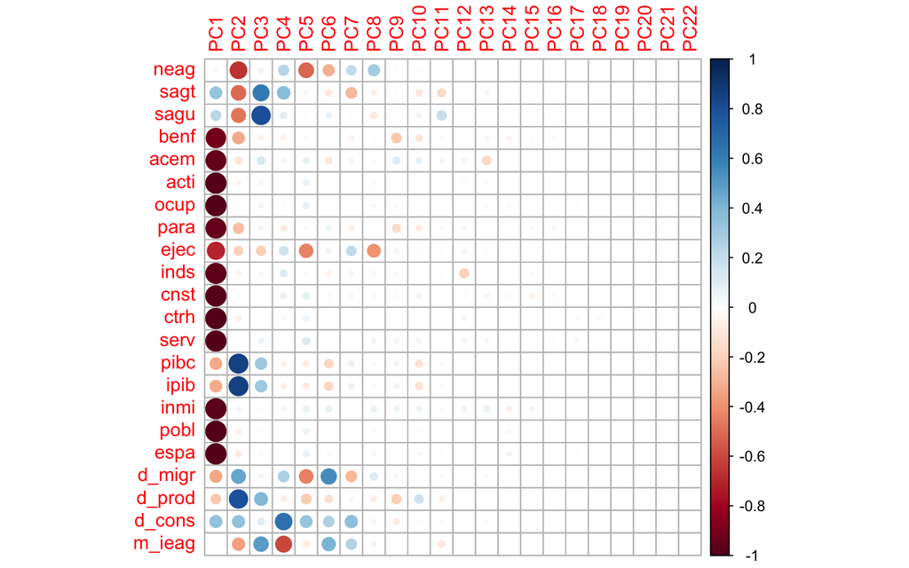

```r
corr_var <- pca$rotation %*% diag(pca$sdev)
colnames(corr_var) <- c("PC1", "PC2", "PC3", "PC4", "PC5", "PC6", "PC7","PC8", "PC9", "PC10", "PC11", "PC12", "PC13", "PC14", "PC15", "PC16", "PC17", "PC18", "PC19", "PC20", "PC21", "PC22")
corrplot(corr_var)
```

Si nos fijamos en los pesos más altos, podemos darle una interpretación a cada eje. Por ejemplo:

- La **primera componente** explica un 56.9% de la variación. Hay valores absolutos bastante similares y elevados (en rojo), que son los relativos a las variables socio-demográficas que hemos comentado antes, y son los que esencialmente está capturando la Componente 1. Teniendo en cuenta los signos podemos concluir que todas ellas influyen negativamente en la componente 1 ya que la correlación es negativa.
- La **segunda componente** explica un 16.9% de variación adicional, los pesos más elevados corresponden con las variables *pibpc* e *ibipc* y puesto que tienen signo positivo, estás están correlacionadas positivamente con la Componente 2. Vemos que esta componente describe principalmente esas dos variables, que hablan del comportamiento economico del país.
- La **tercera componente** explica un 7.8% de variación adicional, los pesos más elevados corresponden con las variables *sagt* e *sagu* (correlacionada positivamente) y que describe principalmente las características agrícolas del país.

## Representación gráfica

**Gráfico de las variables**

Representamos sobre las dos primeras componentes principales las variables originales. En el eje de abscisas se representa la PC1 y en el eje de ordenadas, la PC2. Para interpretar correctamente las variables tenemos que fijarnos en la longitud de la flecha y en el ángulo que forman respecto a los ejes y entre ellos mismos.

- **Ángulo vector - eje**: cuanto más paralelo es un vector al eje, más ha contribuido a dicha componente principal.
- **Ángulo entre dos vectores**: si es pequeño representa una alta correlación entre las variables implicadas (y por tanto, observaciones con valores altos en una variable, tendrá valores altos en la otra). Si el ángulo es cercano a 90º indica que las variables están incorreladas y los ángulos opuestos indican correlación negativa entre ellas.
- **Longitud**: cuanto mayor es la longitud de un vector, mayor varianza de la variable está contenida en el biplot, es decir, mejor representada está en el gráfico.

En el gráfico, diferenciamos por colores las variables según su calidad de representación en las dos primeras componentes. Cuanto más cerca esté una variable del círculo de correlaciones, mejor será su representación, por lo que las variables que estén muy cerca del centro de la gráfica son las menos importantes para las dos primeras componentes.

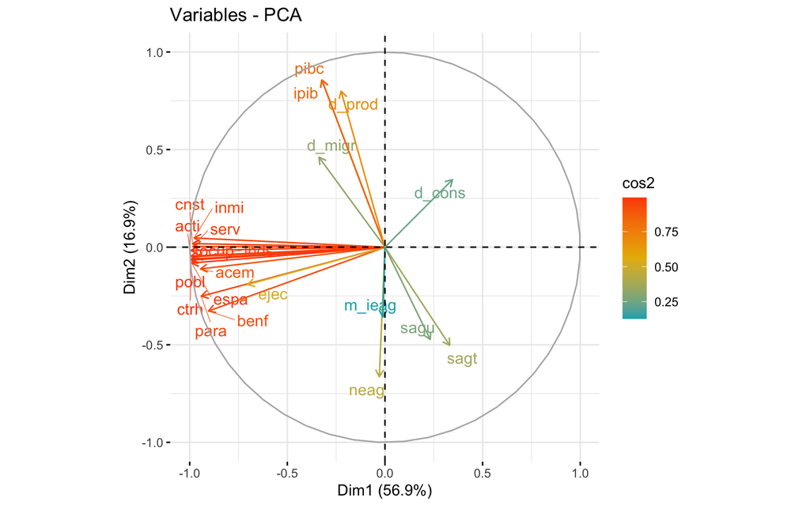

```r
fviz_pca_var(pca, axes = c(1, 2), col.var = "cos2", gradient.cols = c("#00AFBB", "#E7B800", "#FC4E07"), repel = TRUE)
```

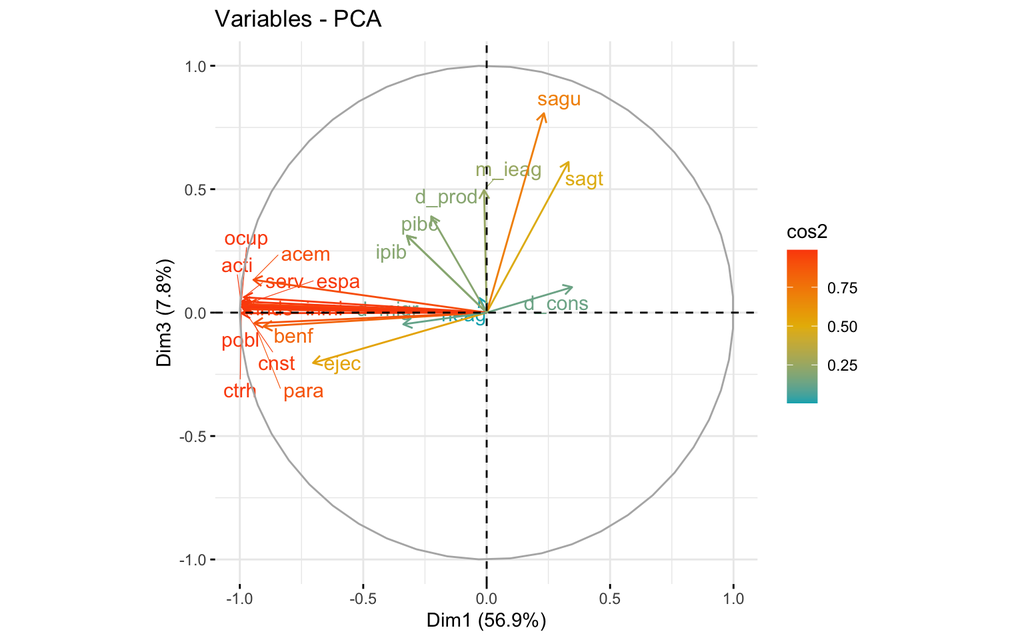

```r
fviz_pca_var(pca, axes = c(1, 3), col.var = "cos2", gradient.cols = c("#00AFBB", "#E7B800", "#FC4E07"), repel = TRUE)
```

- Si nos fijamos en el eje de abscisas, todas variables que hemos visto correlacionadas con la componente 1 de manera alta se situan con menor ángulo respecto a él, indicando que han contribuído a la formación de la PC1. Además hay muy poco ángulo entre ellas puesto que se encuentran altamente correlacionadas entre sí.
- En cuanto al eje de ordenadas, vemos que las variables que forman un menor ángulo respecto a él, son las que más contribuían a la formación de la PC2, tanto de forma positiva como negativa.

**RESUMEN DE RESULTADOS**

Los gráficos obtenidos muestran una visualización de las variables en función de las componentes principales 1 y 2, y 1 y 3. Las variables que tienen una correlación alta con la primera componente principal están más cerca del eje horizontal y las variables que tienen una alta correlación con la segunda componente principal están más cerca del eje vertical. Las variables que se encuentran cerca del centro del gráfico tienen una correlación baja con ambas componentes principales, aún así nos guiaremos con la tabla para decidir qué variables están mejor explicadas por cada una de las componentes. En resumen, estos gráficos proporcionan una representación visual de las relaciones entre las variables en función de las dos primeras componentes principales y las dos segundas, lo que puede ayudar a identificar patrones y tendencias en los datos.

En el siguiente gráfico podemos ver las correlaciones de dichas variables con las componentes principales, como ya hemos comentado.

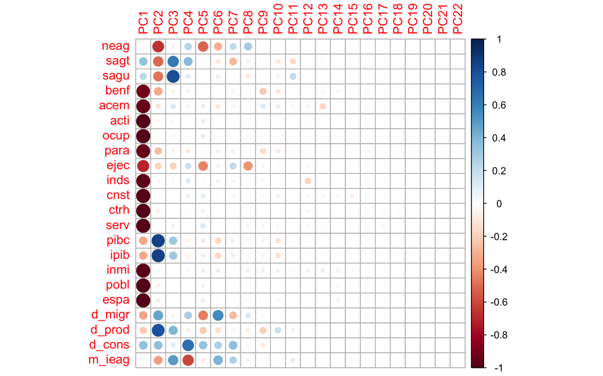

```r
corr_var <- pca$rotation %*% diag(pca$sdev)
colnames(corr_var) <- c("PC1", "PC2", "PC3", "PC4", "PC5", "PC6", "PC7","PC8", "PC9", "PC10", "PC11", "PC12", "PC13", "PC14", "PC15", "PC16", "PC17", "PC18", "PC19", "PC20", "PC21", "PC22")
corrplot(corr_var)
```

En cuanto a este gráfico, es llamativo como las dos o tres primeras componentes son las más importantes en el PCA, sobre todo la PC1 que es la que mas variables resume.

**Gráfico de los individuos**

Tras observar la representación de las variables, en este apartado vemos la representación de los individuos sobre los nuevos ejes, con la idea de que aquellos con características similares, se agrupan cerca al tener puntuaciones parecidas. Las provincias con valores cercanos a la media se situarán cerca del centro del gráfico (0,0).

Vemos que los más lejanos son Madrid y Barcelona en el gráfico de las primeras dos componentes.

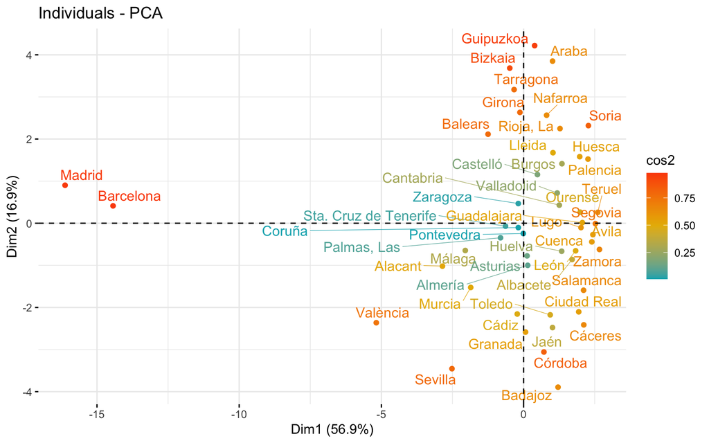

```r
# Sobre PC1 y PC2
fviz_pca_ind(pca, col.ind = "cos2", gradient.cols = c("#00AFBB", "#E7B800", "#FC4E07"), repel = TRUE, axes = c(1, 2))
```

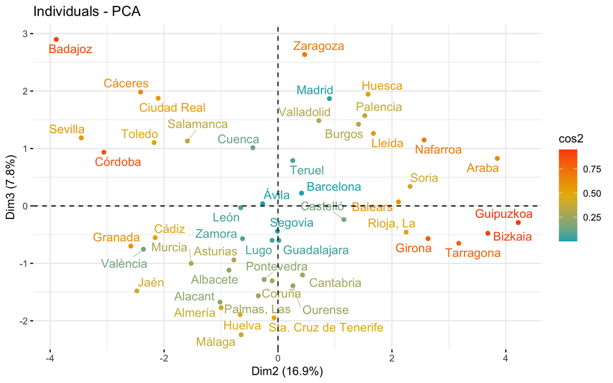

```r
fviz_pca_ind(pca, col.ind = "cos2", gradient.cols = c("#00AFBB", "#E7B800", "#FC4E07"), repel = TRUE, axes = c(2, 3))
```

Las provinicias que se encuentren cerca indican similutd para las componentes que se están representando en el gráfico.

# Conclusiones

El objetivo de este estudio era, partiendo de un conjunto de datos demográfico-económicos sobre la población en provincias en españa, extraer en qué situación se encuentra cada provincia y así identificar cuáles son las provincias con un perfil más parecido entre sí.

Tras haber aplicado la técnica de PCA, hemos concluido que:

- La **primera componente** resume para cada provincia los datos relativos a las variables socio-demográficas que hemos comentado antes. Teniendo en cuenta los signos podemos concluir que todas ellas influyen negativamente en la componente 1 ya que la correlación es negativa.
- La **segunda componente** resume para cada provincia los datos que corresponden con las variables *pibpc* e *ibipc* , que hablan del comportamiento economico del país.
- La **tercera componente**resume para cada provincia los datos que corresponden con las variables *sagt* e *sagu* (correlacionada positivamente) y que describe principalmente las características agrícolas del país.
[^1]: EDA viene del Inglés *Exploratory Data Analysis* y son los pasos relativos en los que se exploran las variables para tener una idea de que forma toma el dataset.